# W3cubDocs

# sklearn.gaussian_process.GaussianProcessRegressor

**`class sklearn.gaussian_process.GaussianProcessRegressor(kernel=None, alpha=1e-10, optimizer=’fmin_l_bfgs_b’, n_restarts_optimizer=0, normalize_y=False, copy_X_train=True, random_state=None)` [[source]](https://github.com/scikit-learn/scikit-learn/blob/bac89c2/sklearn/gaussian_process/gpr.py#L22)**

Gaussian process regression (GPR).

The implementation is based on Algorithm 2.1 of Gaussian Processes for Machine Learning (GPML) by Rasmussen and Williams.

In addition to standard scikit-learn estimator API, GaussianProcessRegressor:

- allows prediction without prior fitting (based on the GP prior)
- provides an additional method sample_y(X), which evaluates samples drawn from the GPR (prior or posterior) at given inputs
- exposes a method log_marginal_likelihood(theta), which can be used externally for other ways of selecting hyperparameters, e.g., via Markov chain Monte Carlo.

Read more in the User Guide.

New in version 0.18.

Parameters:

**`kernel : kernel object`**

The kernel specifying the covariance function of the GP. If None is passed, the kernel “1.0 * RBF(1.0)” is used as default. Note that the kernel’s hyperparameters are optimized during fitting.

**`alpha : float or array-like, optional (default: 1e-10)`**

Value added to the diagonal of the kernel matrix during fitting. Larger values correspond to increased noise level in the observations. This can also prevent a potential numerical issue during fitting, by ensuring that the calculated values form a positive definite matrix. If an array is passed, it must have the same number of entries as the data used for fitting and is used as datapoint-dependent noise level. Note that this is equivalent to adding a WhiteKernel with c=alpha. Allowing to specify the noise level directly as a parameter is mainly for convenience and for consistency with Ridge.

**`optimizer : string or callable, optional (default: “fmin_l_bfgs_b”)`**

Can either be one of the internally supported optimizers for optimizing the kernel’s parameters, specified by a string, or an externally defined optimizer passed as a callable. If a callable is passed, it must have the signature:

```
def optimizer(obj_func, initial_theta, bounds):
    # * 'obj_func' is the objective function to be minimized, which
    #   takes the hyperparameters theta as parameter and an
    #   optional flag eval_gradient, which determines if the
    #   gradient is returned additionally to the function value
    # * 'initial_theta': the initial value for theta, which can be
    #   used by local optimizers
    # * 'bounds': the bounds on the values of theta
    ....
    # Returned are the best found hyperparameters theta and
    # the corresponding value of the target function.
    return theta_opt, func_min
```

Per default, the ‘fmin_l_bfgs_b’ algorithm from scipy.optimize is used. If None is passed, the kernel’s parameters are kept fixed. Available internal optimizers are:

```
'fmin_l_bfgs_b'
```

**`n_restarts_optimizer : int, optional (default: 0)`**

The number of restarts of the optimizer for finding the kernel’s parameters which maximize the log-marginal likelihood. The first run of the optimizer is performed from the kernel’s initial parameters, the remaining ones (if any) from thetas sampled log-uniform randomly from the space of allowed theta-values. If greater than 0, all bounds must be finite. Note that n_restarts_optimizer == 0 implies that one run is performed.

**`normalize_y : boolean, optional (default: False)`**

Whether the target values y are normalized, i.e., the mean of the observed target values become zero. This parameter should be set to True if the target values’ mean is expected to differ considerable from zero. When enabled, the normalization effectively modifies the GP’s prior based on the data, which contradicts the likelihood principle; normalization is thus disabled per default.

**`copy_X_train : bool, optional (default: True)`**

If True, a persistent copy of the training data is stored in the object. Otherwise, just a reference to the training data is stored, which might cause predictions to change if the data is modified externally.

**`random_state : int, RandomState instance or None, optional (default: None)`**

The generator used to initialize the centers. If int, random_state is the seed used by the random number generator; If RandomState instance, random_state is the random number generator; If None, the random number generator is the RandomState instance used by `np.random`.

Attributes:

**`X_train_ : array-like, shape = (n_samples, n_features)`**

Feature values in training data (also required for prediction)

**`y_train_ : array-like, shape = (n_samples, [n_output_dims])`**

Target values in training data (also required for prediction)

**`kernel_ : kernel object`**

The kernel used for prediction. The structure of the kernel is the same as the one passed as parameter but with optimized hyperparameters

**`L_ : array-like, shape = (n_samples, n_samples)`**

Lower-triangular Cholesky decomposition of the kernel in `X_train_`

**`alpha_ : array-like, shape = (n_samples,)`**

Dual coefficients of training data points in kernel space

**`log_marginal_likelihood_value_ : float`**

The log-marginal-likelihood of `self.kernel_.theta`

#### Examples

```
>>> from sklearn.datasets import make_friedman2
>>> from sklearn.gaussian_process import GaussianProcessRegressor
>>> from sklearn.gaussian_process.kernels import DotProduct, WhiteKernel
>>> X, y = make_friedman2(n_samples=500, noise=0, random_state=0)
>>> kernel = DotProduct() + WhiteKernel()
>>> gpr = GaussianProcessRegressor(kernel=kernel,
...         random_state=0).fit(X, y)
>>> gpr.score(X, y)
0.3680...
>>> gpr.predict(X[:2,:], return_std=True)
(array([653.0..., 592.1...]), array([316.6..., 316.6...]))
```

#### Methods

| `fit`(X, y) | Fit Gaussian process regression model. |
| --- | --- |
| `get_params`([deep]) | Get parameters for this estimator. |
| `log_marginal_likelihood`([theta, eval_gradient]) | Returns log-marginal likelihood of theta for training data. |
| `predict`(X[, return_std, return_cov]) | Predict using the Gaussian process regression model |
| `sample_y`(X[, n_samples, random_state]) | Draw samples from Gaussian process and evaluate at X. |
| `score`(X, y[, sample_weight]) | Returns the coefficient of determination R^2 of the prediction. |
| `set_params`(**params) | Set the parameters of this estimator. |

**`__init__(kernel=None, alpha=1e-10, optimizer=’fmin_l_bfgs_b’, n_restarts_optimizer=0, normalize_y=False, copy_X_train=True, random_state=None)` [[source]](https://github.com/scikit-learn/scikit-learn/blob/bac89c2/sklearn/gaussian_process/gpr.py#L150)**

**`fit(X, y)` [[source]](https://github.com/scikit-learn/scikit-learn/blob/bac89c2/sklearn/gaussian_process/gpr.py#L173)**

Fit Gaussian process regression model.

| Parameters: | **`X : array-like, shape = (n_samples, n_features)`** Training data **`y : array-like, shape = (n_samples, [n_output_dims])`** Target values |
| --- | --- |
| Returns: | **`self : returns an instance of self.`** |

**`get_params(deep=True)` [[source]](https://github.com/scikit-learn/scikit-learn/blob/bac89c2/sklearn/base.py#L166)**

Get parameters for this estimator.

| Parameters: | **`deep : boolean, optional`** If True, will return the parameters for this estimator and contained subobjects that are estimators. |
| --- | --- |
| Returns: | **`params : mapping of string to any`** Parameter names mapped to their values. |

**`log_marginal_likelihood(theta=None, eval_gradient=False)` [[source]](https://github.com/scikit-learn/scikit-learn/blob/bac89c2/sklearn/gaussian_process/gpr.py#L400)**

Returns log-marginal likelihood of theta for training data.

[output not shown]

**`predict(X, return_std=False, return_cov=False)` [[source]](https://github.com/scikit-learn/scikit-learn/blob/bac89c2/sklearn/gaussian_process/gpr.py#L275)**

Predict using the Gaussian process regression model

We can also predict based on an unfitted model by using the GP prior. In addition to the mean of the predictive distribution, also its standard deviation (return_std=True) or covariance (return_cov=True). Note that at most one of the two can be requested.

[output not shown]

**`rng`**

DEPRECATED: Attribute rng was deprecated in version 0.19 and will be removed in 0.21.

**`sample_y(X, n_samples=1, random_state=0)` [[source]](https://github.com/scikit-learn/scikit-learn/blob/bac89c2/sklearn/gaussian_process/gpr.py#L364)**

Draw samples from Gaussian process and evaluate at X.

[output not shown]

**`score(X, y, sample_weight=None)` [[source]](https://github.com/scikit-learn/scikit-learn/blob/bac89c2/sklearn/base.py#L296)**

Returns the coefficient of determination R^2 of the prediction.

The coefficient R^2 is defined as (1 - u/v), where u is the residual sum of squares ((y_true - y_pred) ** 2).sum() and v is the total sum of squares ((y_true - y_true.mean()) ** 2).sum(). The best possible score is 1.0 and it can be negative (because the model can be arbitrarily worse). A constant model that always predicts the expected value of y, disregarding the input features, would get a R^2 score of 0.0.

[output not shown]

**`set_params(**params)` [[source]](https://github.com/scikit-learn/scikit-learn/blob/bac89c2/sklearn/base.py#L189)**

Set the parameters of this estimator.

The method works on simple estimators as well as on nested objects (such as pipelines). The latter have parameters of the form `<component>__<parameter>` so that it’s possible to update each component of a nested object.

| Returns: | **self** |
| --- | --- |

**`y_train_mean`**

DEPRECATED: Attribute y_train_mean was deprecated in version 0.19 and will be removed in 0.21.

## Examples using `sklearn.gaussian_process.GaussianProcessRegressor`

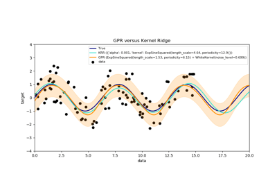

Comparison of kernel ridge and Gaussian process regression

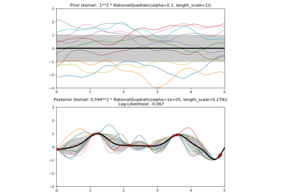

Illustration of prior and posterior Gaussian process for different kernels

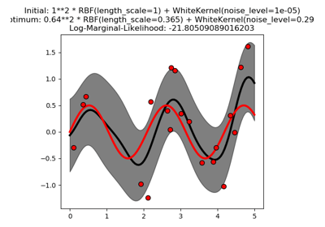

Gaussian process regression (GPR) with noise-level estimation

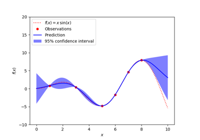

Gaussian Processes regression: basic introductory example

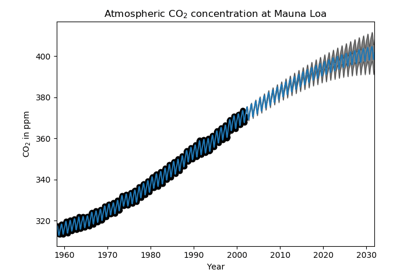

Gaussian process regression (GPR) on Mauna Loa CO2 data.

© 2007–2018 The scikit-learn developers  
Licensed under the 3-clause BSD License.  
http://scikit-learn.org/stable/modules/generated/sklearn.gaussian_process.GaussianProcessRegressor.html